# RR WEEK 2 - COURSE PROJECT 1

# 1. Loading and preprocessing data

Here is the code for reading in and preprocessing the data.

```r
library(ggplot2) # load required packages

data <- read.csv("activity.csv") # read in data
data_clean <- data[!is.na(data$steps),] # remove rows with NA values i.e. consider only clean/tidy data
```

```r
knitr::opts_chunk$set(fig.path='Figs/')
```

# 2. Histogram of the total number of steps taken each day.

For the clean data the total number of steps is calculated and plotted in a histogram.

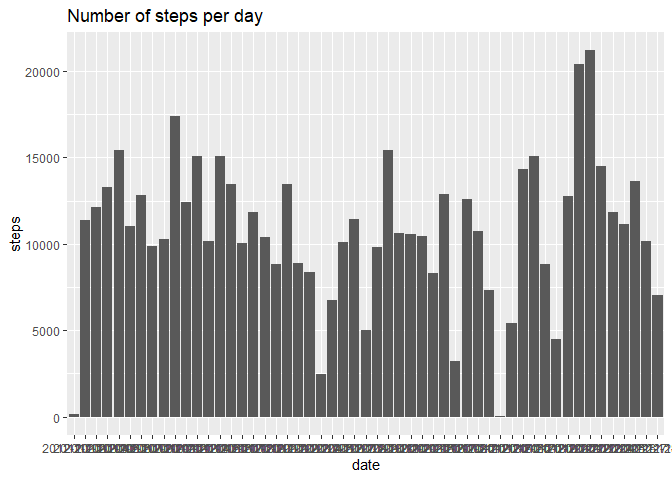

```r
sum_steps <- aggregate(data_clean$steps, by = list(data_clean$date), sum) # sum steps of clean data per date
names(sum_steps) <- c("date","steps") # rename columns of result

hist_steps <- ggplot(sum_steps, aes(date,steps)) + geom_histogram(stat = "identity")+ ggtitle("Number of steps per day")  # create histogram
print(hist_steps)
```

# 3. Mean and median of total number of steps

Furthermore, mean and median of the total number of steps is calculated.

```r
mean(sum_steps$steps) # calculate mean
```

```
## [1] 10766.19
```

```r
median(sum_steps$steps) # calculate median
```

```
## [1] 10765
```

# 4. Time series plot of the average number of steps taken

Next, the average number of steps is calculated per interval and plotted in a time series.

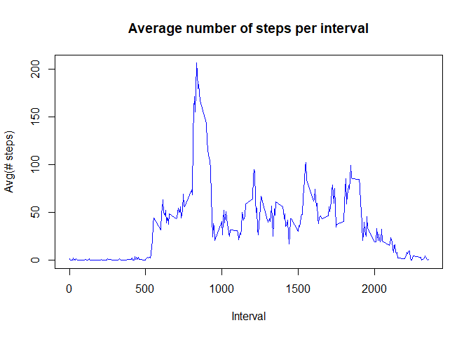

```r
mean_int <- aggregate(data_clean$steps,by = list(data_clean$interval), mean) # calculate average number of steps per interval
names(mean_int) <- c("interval","mean(steps)") # rename columns of result

plot(mean_int$interval, mean_int$`mean(steps)`, type = "l", xlab = "Interval", ylab = "Avg(# steps)",
    main = "Average number of steps per interval", col = "blue") # create time series
```

# 5. The 5-minute interval that, on average, contains the maximum number of steps

This interval is calculated as follows:

```r
mean_int[mean_int[,2] == max(mean_int$`mean(steps)`), 1] # determine interval with maximum numver of steps
```

```
## [1] 835
```